# Spatial Assignment - Habitat Suitability Analysis for the Pacific Spiny Lumpsucker

Erik J Ortega & Zack Dinh

# Exercise

This module is inspired by a recent paper in Nature Ecology and Evolution, [**Mapping the global potential for marine aquaculture**](https://www.nature.com/articles/s41559-017-0257-9). The authors used multiple constraints including ship traffic, dissolved oxygen, bottom depth and more, to limit and map areas suitable for aquaculture.

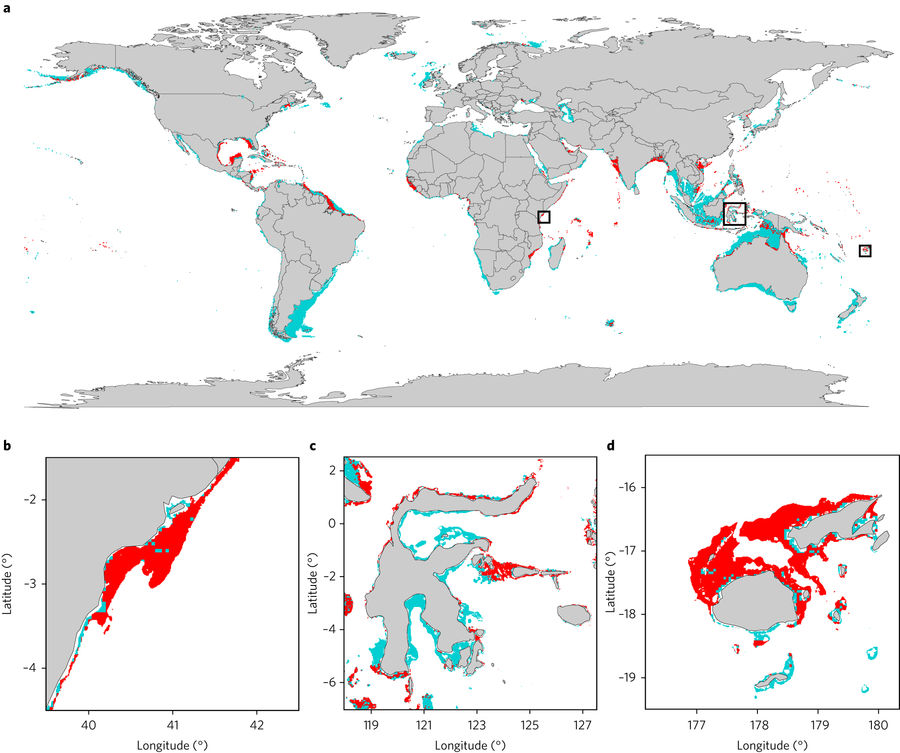

We are going to use a similar, but much more simplified approach here. We will map potential areas of marine aquaculture for the super cute Pacific spiny lumpsucker (*Eumicrotremus orbis*)

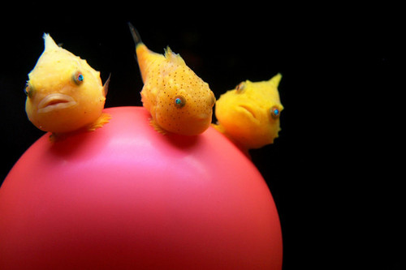

They have adhesive pelvic disks! How cute!

To do this we are going to need the following spatial data:

**1. Sea Surface Temperature** (raster data)  
**2. Net Primary Productivity** (raster data)  
**3. Marine Protected Areas** (vector data)

## Exercise 1: Play with Vector Data

So to figure out where we might find the lumpsucker fish, we need to know a little about it!

From [NOAA’s species description](http://www.nmfs.noaa.gov/speciesid/fish_page/fish68a.html):

> A lot of people who see Pacific spiny lumpsuckers for the first time describe them as a ping-pong ball with fins. They are tiny and very inefficient swimmers, found most often in kelp or eelgrass beds attached to a rock or a log no deeper than 500 feet. They are quite common, ranging from the waters off the Washington coast, up around the arc of the Aleutian Islands, to the Asian mainland and the northern islands of Japan, and in the Bering Sea. A giant Pacific spiny lumpsucker is five inches long, but most are closer to an inch. Scuba divers are their biggest fans because the little fellows will eat right out of their hands.

Key information for optimal growth:

- Sea surface temperatures between **12 and 18 degrees Celsius**
- Net Primary Productivity between **2.6 and 3 mgC/m2/day**

### Task 1: Load and Visualize data

We’ll start with a data file of Marine Protected Areas monitored by the US Federal government on the west coast: `mpas_westcoast.shp`. This is found in your `shapefiles` directory. Load this in using the `st_read` function.

```r
#load west coast marine protected areas shapefile
mpas <- st_read("shapefiles/mpas_westcoast.shp")
#use heaad(mpas) to inspect
#head(mpas)
```

### Map of West Coast Marine Protected Areas

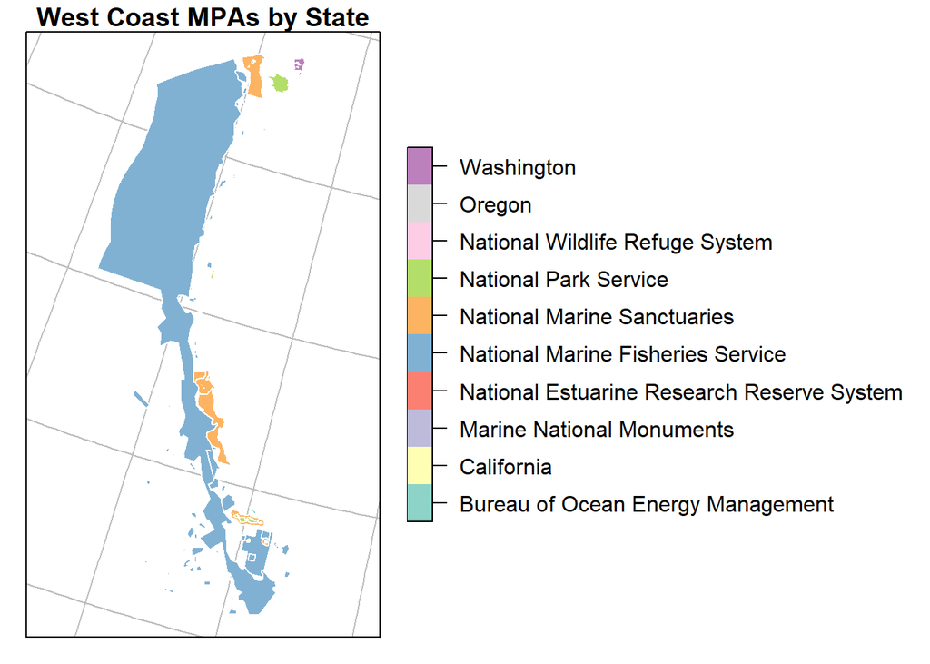

```r
#plot west coast marine protected areas shapefile
plot(mpas["State"], main = "West Coast MPAs by State", pal = sf.colors(10, categorical = TRUE), border = 'white',
     axes = FALSE, key.pos = 4, key.width = lcm(10), graticule = TRUE)
```

```r
#ggplot method
#mpas %>% ggplot() + geom_sf(aes(col = State))
```

### Task 3

How much protected marine habitat does each state or agency control? The National Marine Fisheries Service contorls the largest amount of marine habitat (387,058.3 square kilometers). The table below, in descening order states total area for each entity.

```r
mpas %>%
    select(State, Area_KM_To) %>%
    group_by(State) %>%
    summarise(TotalArea = sum(Area_KM_To)) %>%
    arrange(desc(TotalArea))
```

```
## Simple feature collection with 10 features and 2 fields
## geometry type:  GEOMETRY
## dimension:      XY
## bbox:           xmin: -2707616 ymin: -457193.8 xmax: -1950642 ymax: 1553906
## epsg (SRID):    NA
## proj4string:    +proj=aea +lat_1=29.5 +lat_2=45.5 +lat_0=37.5 +lon_0=-96 +x_0=0 +y_0=0 +datum=NAD83 +units=m +no_defs
## # A tibble: 10 x 3
##    State               TotalArea                                  geometry
##    <fct>                   <dbl>                            <GEOMETRY [m]>
##  1 National Marine Fi~ 387058.   MULTIPOLYGON (((-2022333 -317282.9, -202~
##  2 National Marine Sa~  32591.   MULTIPOLYGON (((-2093543 -191307.6, -209~
##  3 National Park Serv~   5851.   MULTIPOLYGON (((-2103158 -191604.2, -210~
##  4 California            4620.   MULTIPOLYGON (((-1957131 -333326.9, -195~
##  5 Washington            2218.   MULTIPOLYGON (((-2114207 1331625, -21141~
##  6 National Wildlife ~    619.   MULTIPOLYGON (((-1956125 -332742.8, -195~
##  7 Bureau of Ocean En~    224.   POLYGON ((-2131762 -84901.34, -2131745 -~
##  8 National Estuarine~    103.   MULTIPOLYGON (((-1956380 -332373.5, -195~
##  9 Oregon                  27.7  MULTIPOLYGON (((-2291710 852562.4, -2291~
## 10 Marine National Mo~      7.72 MULTIPOLYGON (((-1964285 -319058.9, -196~
```

## Exercise 2: Load and Play with Raster data

**Sea Surface Temperature**

In the `rasters` folder, there are 5 `.tif` files with the naming pattern `average_annual_sst_[year].tif`, which are 5 annual average sea surface temperatures for our region (2008-2012). We want just **one** raster file of the average SST over that time period.

### Task 1: Read in raster data

To create a single average Sea Surface Temperature layer, you’ll first need to read in all 5 data files (try adapting the `list.files()` function). To read them all in, you’ll use the `raster` function. This is a good place to try the `map` function too!

```r
files <- list.files("rasters/", pattern = "average", full.names = TRUE)
```

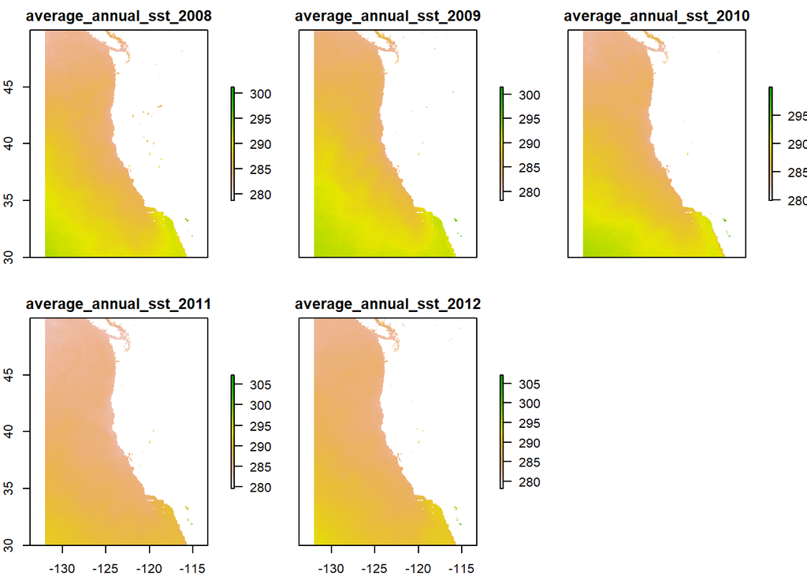

```r
rasterstack <- stack(files)
plot(rasterstack)
```

### Task 2: Visualize & Explore

*Notice the data values are in Kelvin - we will change this to celsius later.*

Try exploring the data, using basic functions like `hist()`, or `summary()`

```r
summary(rasterstack)
```

```
##         average_annual_sst_2008 average_annual_sst_2009
## Min.                   278.7000                278.0800
## 1st Qu.                285.2526                285.6945
## Median                 287.1172                287.7019
## 3rd Qu.                289.1167                289.7083
## Max.                   301.2700                301.5000
## NA's                 81869.0000              81992.0000
##         average_annual_sst_2010 average_annual_sst_2011
## Min.                   279.9200                279.5000
## 1st Qu.                285.6521                285.4800
## Median                 287.3965                286.9784
## 3rd Qu.                289.3566                288.7772
## Max.                   299.9800                307.2733
## NA's                 82088.0000              81749.0000
##         average_annual_sst_2012
## Min.                   278.1300
## 1st Qu.                285.5408
## Median                 286.9897
## 3rd Qu.                289.0179
## Max.                   307.1300
## NA's                 81640.0000
```

#### Question: What year had the highest annual sea surface temperature recorded?

The highest annual sea surface temperature was in 2011 with a max of 307.2733 K.

### Task 4: Stack rasters

To get a single layer of average SST in degrees Celsius we need to first `stack` all layers.

[figure not shown]

`stack` is a function from the raster package that puts all RasterLayers into a RasterStack. It can stack either from filenames for rasters, or from the raster objects themselves. Produce a rasterstack of Average Sea Surface Temperature across all 5 years. Try using the `plot` function to visualize the stack.

### Task 5: Raster calcuations

We want to take this stack of 5 rasters and make one. Additionally for easier interpretation, we want our averaged raster in Celsius. The conversion between Kelvin and Celsius is: $C = K - 273.15$

This collapse and conversion could be done in multiple steps, but since we like to emphasize concision in our coding, let’s instead write a small custom function to take the mean and convert to Celsius. We will then apply this function to our rasterstack to calculate a new raster we can use for analysis.

Write your custom R function.

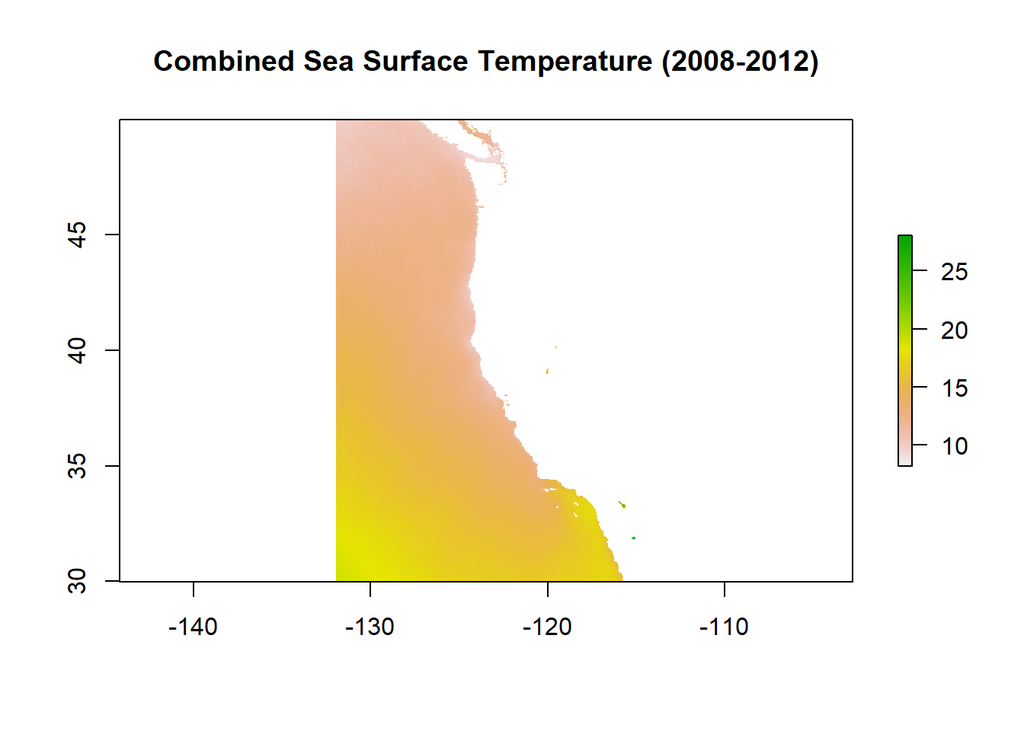

```r
converter <- function(rasterdata) {
  calc(rasterdata, fun = mean) - 273.15
}

combined_sst <- converter(rasterstack)

plot(combined_sst, main = "Combined Sea Surface Temperature (2008-2012)")
```

## Exercise 3: Projections

Since Lumpsuckers may be influenced by more than just sea surface temperature, we want to include **Net Primary Production (NPP)** in our analysis. So we need to read that in too and create a rasterstack of ur new `sst_avg` raster and the NPP layer.

#### Task 1: Read in NPP raster data

Read in the NPP data, using the `raster()` command and the “annual_npp.tif” found in the rasters folder. This data is the net primary production (mgC/m2/day). After reading it in, plot this data.

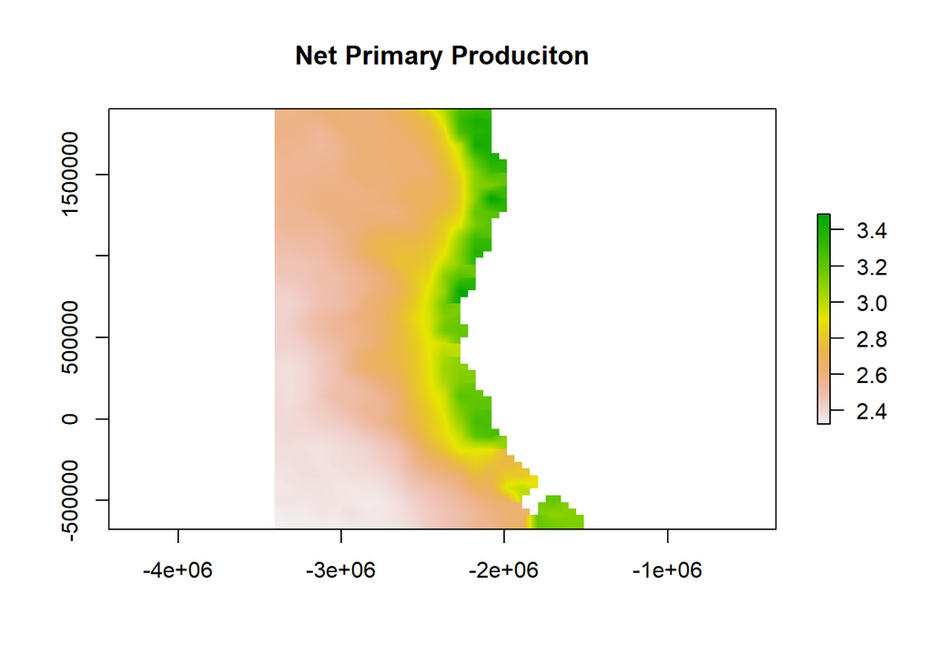

```r
npp <- raster("rasters/annual_npp.tif")
plot(npp, main = "Net Primary Produciton")
```

### Task 2: Reproject

Try adding these two layers together using `stack` and you’ll get an error because these rasters are not in the same “projection” - pretty obvious from the plots. In order to do analysis across multiple spatial datasources, they must be using the same coordinate reference system.

Use the `crs()` command to see what coordinate system each of your rasters are using and, for good measure, use the `st_crs` command to investigate the crs of our vector data, `west_coast`, from above:

```r
#stack will error
#stack(combined_sst, npp)
```

```r
crs(combined_sst)
```

```
## CRS arguments: +proj=longlat +ellps=WGS84 +no_defs
```

```r
crs(npp)
```

```
## CRS arguments:
##  +proj=aea +lat_1=29.5 +lat_2=45.5 +lat_0=37.5 +lon_0=-96 +x_0=0
## +y_0=0 +ellps=GRS80 +towgs84=0,0,0,0,0,0,0 +units=m +no_defs
```

```r
st_crs(mpas)
```

```
## Coordinate Reference System:
##   No EPSG code
##   proj4string: "+proj=aea +lat_1=29.5 +lat_2=45.5 +lat_0=37.5 +lon_0=-96 +x_0=0 +y_0=0 +datum=NAD83 +units=m +no_defs"
```

Looks like `npp` is equal to our `west_coast` but our mean SST layer is different! It’s crucial when doing spatial analysis that your projections across all layers are equal. We can use `projectRaster()` from the raster package to reproject a RasterLayer from one projection to another. You will need to define what the new projection should be by setting a coordinate reference system using the argument `crs =`.

Project your average SST layer into npp’s coordinate reference system and prove to yourself they are equal using the `identicalCRS` function.

```r
sst_prj <- projectRaster(combined_sst, crs = crs(npp), asText = TRUE)

identicalCRS(sst_prj, npp)
```

```
## [1] TRUE
```

You will get an error about non-missing arguments here, this is because in order to have our two raster layers match in extent, our SST layer covers a lot of missing values on its edges which `raster` is encountering in the projection. We can ignore this error for now, but if you’re curious about the values of a raster you can always look at them using the `values` command. Try `summary(values(SST_layer))` – how many NAs does our raster have?

It’s important to note that although here we have given you mostly prepared data, in practice the projection may not be the only thing different across your rasters. To do any sort of analysis using multiple rasters, they all need to be in the same extent, projection and cell resolution. You can check this with the command `all.equal()` in the `raster` library*

Okay! now we’re ready to get to some analysis. For convenience, stack the now matching rasters together using the `stack` function and plot them.

```r
summary(values(sst_prj))
```

```
##    Min. 1st Qu.  Median    Mean 3rd Qu.    Max.    NA's
##    8.52   12.52   14.36   14.33   16.19   28.05  225746
```

```r
all.equal(sst_prj, npp)
```

```
## [1] FALSE
```

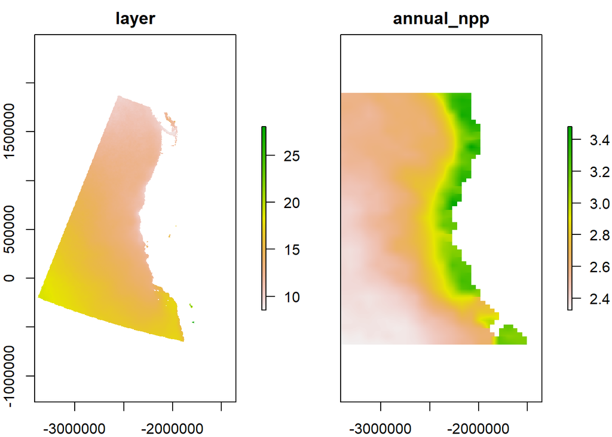

```r
Stack_SST_NPP <- stack(sst_prj, npp)
plot(Stack_SST_NPP)
```

#### Question: Looking at them side by side, do you have intuition about where lumpsuckers are likely to survive?

Remember: Lumpsucker fish grow best in waters that are **between 12 and 18 degrees Celsius.** and with an NPP between **2.6 and 3 mgC/m2/day**